# D213 Task II - Sentiment Analysis using Neural Networks

David Harvell  
Master of Science, Data Analytics  
December 2021

### A-1. Summarize one research question that you will answer using neural network models and NLP techniques. Be sure the research question is relevant to a real-world organizational situation and sentiment analysis captured in your chosen dataset.

We will be concerned with the following question during this analysis - **Can we determine the positive or negative sentiment of a review using Neural Networks?**. We will be using review datasets from Amazon, IMDB, and Yelp.

### A-2. Define the objectives or goals of the data analysis. Be sure the objectives or goals are reasonable within the scope of the research question and are represented in the available data.

If we are able to create a reliable model, **we can use Neural Networks to process millions of reviews and determine sentiment for our products**. This method would be exponential faster than having humans process the data, and it could deliver insights that previously had a high barrier of entry.

### A-3. Identify a type of neural network capable of performing a text classification task that can be trained to produce useful predictions on text sequences on the selected data set.

We will use a standard **Sequential ANN (Artificial Neural Network) employing Embedding for stronger word associations** with an end goal of binary classification. Preliminary testing was done using the Recurrent Network of LSTM, but the accuracy wasn't close enough to make confident predictions with the included datasets.

### B-1. Perform exploratory data analysis on the chosen dataset, and include an explanation of each of the following elements:</span>

- presence of unusual characters (e.g., emojis, non-English characters, etc.)
- vocabulary size
- proposed word embedding length
- statistical justification for the chosen maximum sequence length

**We begin by importing necessary libraries and importing the data.**

```python
from google.colab import drive
drive.mount('/content/drive')
```

```python
import pandas as pd
import tensorflow as tf
import matplotlib.pyplot as plt
from tensorflow import keras
```

```python
# Prep to load the 3 files from Google Drive
path = '/content/drive/My Drive/School/Datasets/' # the absolute path to your file
files = ['amazon.txt', 'imdb.txt', 'yelp.txt']
df_list = []

# Loop through files creating list of dataframes
for idx, file in enumerate(files):
    df = pd.read_csv(path + file, sep='\t', names=['Review', 'Sentiment'], header=None, quoting=3)
    df['ReviewSource'] = idx
    df_list.append(df)

# Blend into one final dataframe and review info
df = pd.concat(df_list)
df.reset_index(drop=True, inplace=True)
df.info()
```

```
<class 'pandas.core.frame.DataFrame'>
RangeIndex: 3000 entries, 0 to 2999
Data columns (total 3 columns):
 #   Column        Non-Null Count  Dtype
---  ------        --------------  -----
 0   Review        3000 non-null   object
 1   Sentiment     3000 non-null   int64
 2   ReviewSource  3000 non-null   int64
dtypes: int64(2), object(1)
memory usage: 70.4+ KB
```

**1. Non-alpha characters - We will cleanse the data to remove non-alpha values and excessive punctuations.**

```python
# Make all words the same case
df.Review = df.Review.str.lower()

# Remove puncuation to focus on words
df.Review = df.Review.str.replace(r'[^\w\s]+', '')
df.Review = df.Review.str.strip()

# Collect the length of review in case it can be used later
df['ReviewLength'] = df.Review.str.len()

# Preview data
df.head()
```

|  | Review | Sentiment | ReviewSource | ReviewLength |
| --- | --- | --- | --- | --- |
| 0 | so there is no way for me to plug it in here i... | 0 | 0 | 81 |
| 1 | good case excellent value | 1 | 0 | 25 |
| 2 | great for the jawbone | 1 | 0 | 21 |
| 3 | tied to charger for conversations lasting more... | 0 | 0 | 76 |
| 4 | the mic is great | 1 | 0 | 16 |

```python
# Create a list of the reviews and initialize variables for the vocabulary and max review length
reviews = df['Review'].tolist()
vocab = []
max_review_len = 0

# Loop throw the reviews, building our vocabulary and keeping track of the max review length
for review in reviews:
  review_len = len(review.split(" "))
  if review_len > max_review_len:
      max_review_len = review_len

  for word in review.split(" "):
    if not word in vocab:
      vocab.append(word)

print("Vocab:    ", len(vocab))
print("Longest:  ", max_review_len)
print("Emb Size: ", len(vocab)**0.25)
```

```
Vocab:     5402
Longest:   71
Emb Size:  8.573114912332146
```

**2. The vocabulary size is 5,402 distinct words.**

**3. Based on the vocabulary length, the suggested Embedding length is 8.6. We will move up to 12 to make sure sufficient compute is used. This number is derived using the number of categories to the power of 1/4, based on suggestions from the Google developer blog (Google, 2017).**

**4. Our longest sentence uses 71 words, so that will be our target when padding the smaller values.**

### B-2. Describe the goals of the tokenization process, including any code generated and packages that are used to normalize text during the tokenization process.</span>

**We will use keras built-in one-hot encoding to translate the words into numeric representations.**

```python
encoded_reviews = [keras.preprocessing.text.one_hot(d, len(vocab)) for d in reviews]
print(encoded_reviews[0])
```

```
[236, 3852, 1947, 90, 1482, 2447, 439, 470, 2196, 4662, 596, 2933, 596, 2085, 4164, 2870, 1208, 2029, 196, 2091, 5270]
```

### B-3. Explain the padding process used to standardize the length of sequences, including the following in your explanation:

- if the padding occurs before or after the text sequence
- a screenshot of a single padded sequence

**We are padding at the end of the reviews to make all sequences the same length as our max sequence (71 words). Below is the summarized result of the padding, followed by the entirety of the first review with padding.**

```python
padded_reviews = keras.preprocessing.sequence.pad_sequences(encoded_reviews, maxlen=max_review_len, padding='post')
print(padded_reviews)
```

```
[[ 236 3852 1947 ...    0    0    0]
 [2047   14   50 ...    0    0    0]
 [4740 2447 2085 ...    0    0    0]
 ...
 [3129 1208  423 ...    0    0    0]
 [2085 4708  649 ...    0    0    0]
 [5355 4917 2981 ...    0    0    0]]
```

```python
padded_reviews[0]
```

```
array([ 236, 3852, 1947,   90, 1482, 2447,  439,  470, 2196, 4662,  596,
       2933,  596, 2085, 4164, 2870, 1208, 2029,  196, 2091, 5270,    0,
          0,    0,    0,    0,    0,    0,    0,    0,    0,    0,    0,
          0,    0,    0,    0,    0,    0,    0,    0,    0,    0,    0,
          0,    0,    0,    0,    0,    0,    0,    0,    0,    0,    0,
          0,    0,    0,    0,    0,    0,    0,    0,    0,    0,    0,
          0,    0,    0,    0,    0], dtype=int32)
```

### B-4. Identify how many categories of sentiment will be used and an activation function for the final dense layer of the network.

**There will only be two categories of sentiment - positive (1) and negative (0). Because of this, we will use the Sigmoid activation function for our final Dense layer.**

### B-5. Explain the steps used to prepare the data for analysis, including the size of the training, validation, and test set split.

```python
from sklearn.model_selection import train_test_split

X_train, X_test, y_train, y_test = train_test_split(padded_reviews, df.Sentiment, test_size=0.2, random_state=7)
```

**Now that data has been encoded for embedding and padded, we split the data into Training and Testing sets. We will be using 80% of the data for training and 20% for testing.**

### B-6. Provide a copy of the prepared dataset.

```python
df_final = pd.DataFrame(padded_reviews)
df_final['Setiment'] = df.Sentiment
df_final.to_csv('sentiment_prepared.csv')
```

**A copy of the prepared data is now saved and will be submitted with the analysis.**

### C-1. Provide the output of the model summary of the function from TensorFlow.

**See below for the model summary.**

```python
model = keras.Sequential()
model.add(keras.layers.Embedding(len(vocab), 12, input_length=max_review_len))
model.add(keras.layers.Flatten())
model.add(keras.layers.Dropout(0.2))
model.add(keras.layers.Dense(16, activation='relu'))
model.add(keras.layers.Dense(1, activation='sigmoid'))
model.compile(optimizer='adam', loss='binary_crossentropy', metrics=['accuracy'])
print(model.summary())
```

```
Model: "sequential_4"
_________________________________________________________________
 Layer (type)                Output Shape              Param #
=================================================================
 embedding_4 (Embedding)     (None, 71, 12)            64824

 flatten_4 (Flatten)         (None, 852)               0

 dropout_4 (Dropout)         (None, 852)               0

 dense_9 (Dense)             (None, 16)                13648

 dense_10 (Dense)            (None, 1)                 17

=================================================================
Total params: 78,489
Trainable params: 78,489
Non-trainable params: 0
_________________________________________________________________
None
```

### C-2. Discuss the number of layers, the type of layers, and total number of parameters.

We are employing 5 layers in our model.

- First is the Embedding layer with 64K parameters, a result of the 5400 words and embedding length of 12
- Second is a Flatten layer to accompany the Embedding layer
- Third is a Dropout layer in an attempt to prevent overfitting
- Fourth is a Dense layer with a 13.6K parameters, a results of the 852 input values and 16 nodes
- Fifth is the final later with 17 parameters - a result of the input values

### C-3. Justify the choice of hyperparameters, including the following elements:

- activation functions
- number of nodes per layer
- loss function
- optimizer
- stopping criteria
- evaluation metric

**1. Activation Functions**  
We are employing two different activation functions. The first is a Rectified Linear Unit. This function returns zero for values below zero, and returns the value itself above zero. ReLU is appropriate for most scenarios (Chen, 2021).  
The second activation function is Sigmoid. We are using this in the final layer because we are moving towards a binary classification. The outputs for Sigmoid range between 0 and 1.  
**2. Nodes per Layer**  
Our first layer is dictated by the number of categoies (words) in our model. For the fourth Dense layer we are using 16 nodes. It is an arbetrary number between the first and last layer node counts, and appeared to work well with the model.  
The final layer is using 1 node, as we try to get the data ready for a binary classification.  
**3. Loss Function**  
Our loss function is Binary Crossentropy. This is the appropriate loss function when there are two possible output values.  
**4. Optimizer**  
We are using Adam for optimization. The Adam optimizer combines the two primary advantages of other optimizers - Adaptive Gradient Algorithm, and Root Mean Squared Propogation (Brownlee, 2021a).  
**5. Stopping Criteria**  
We are employing early stopping during the fitting of our model. We will base the stopping on the min loss value. If we haven't seen consistently equal or lower values for loss after four epochs, we will revert back to the last epoch that showed progress.  
**6. Evaluation Metric**  
Our primiary evaluations are Accuracy and Loss. Loss equates to the error that we seek to minimize with a loss function, and Accuracy is the ratio of correct predictions to the entire set of targets.

### D-1. Discuss the impact of using stopping criteria instead of defining the number of epochs, including a screenshot showing the final training epoch.

**Unrestricted -**

```python
unrestricted = model.fit(X_train, y_train, epochs=20, validation_data=[X_test, y_test])
```

[output not shown]

**With Early Stopping -**

```python
earlystopping = keras.callbacks.EarlyStopping(monitor ="val_loss", mode ="min", patience = 4, restore_best_weights = True)
restricted = model.fit(X_train, y_train, epochs=20, validation_data=[X_test, y_test], callbacks=[earlystopping])
```

```
<keras.callbacks.History at 0x7f75fd5e5f90>
```

### D-2. Provide visualizations of the model’s training process, including a line graph of the loss and chosen evaluation metric.

**Loss Results**

[figure not shown]

```python
plt.plot(unrestricted.history['loss'])
plt.xlabel('Epochs')
plt.ylabel('MAE (loss)')
plt.title('Loss vs Epoch Count')
plt.show()
```

**Accuracy Results**

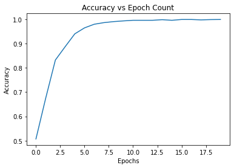

```python
plt.plot(unrestricted.history['accuracy'])
plt.xlabel('Epochs')
plt.ylabel('Accuracy')
plt.title('Accuracy vs Epoch Count')
plt.show()
```

### E. Provide the code used to save the trained network within the neural network.

Code to save the model is below -

```python
# Save the model to JSON
model_json = model.to_json()

with open("sentiment_model_D213.json", "w") as json_file:
  json_file.write(model_json)

# Save the model to HDF5
model.save_weights("sentiment_model_D213.h5")
```

### G. Recommend a course of action based on your results.

Based on our accuracy, we should be able to determine general sentiments of reviews based on the text alone. This will allow fast determinations of the general publics opinion.

### H. Final representation of the model.

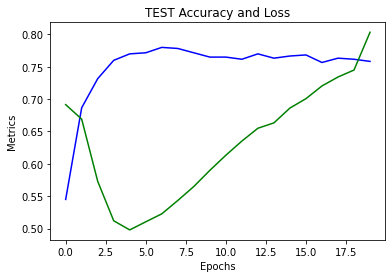

```python
plt.plot(range(len(unrestricted.history['val_accuracy'])), unrestricted.history['val_accuracy'], 'b', label='Accuracy')
plt.plot(range(len(unrestricted.history['val_loss'])), unrestricted.history['val_loss'], 'g', label='Accuracy')
plt.xlabel('Epochs')
plt.ylabel('Metrics')
plt.title('TEST Accuracy and Loss')
plt.figure()
```

### Appendix I - Code References

Janakiev, N. (2021, August 6). Practical Text Classification With Python and Keras. Real Python. Retrieved December 8, 2021, from https://realpython.com/python-keras-text-classification/  
Shekhar, S. (2021, June 30). LSTM for Text Classification | Beginners Guide to Text Classification. Analytics Vidhya. Retrieved December 8, 2021, from https://www.analyticsvidhya.com/blog/2021/06/lstm-for-text-classification/  
GeeksforGeeks. (2020, June 8). Choose optimal number of epochs to train a neural network in Keras. Retrieved December 8, 2021, from https://www.geeksforgeeks.org/choose-optimal-number-of-epochs-to-train-a-neural-network-in-keras/  
Tanwar, S. (2019, December 17). Building our first neural network in keras. Towards Data Science. https://towardsdatascience.com/building-our-first-neural-network-in-keras-bdc8abbc17f5  
Brownlee, J. (2021, February 1). How to Use Word Embedding Layers for Deep Learning with Keras. Machine Learning Mastery. https://machinelearningmastery.com/use-word-embedding-layers-deep-learning-keras/  
Brownlee, J. (2020, August 27). How to Save and Load Your Keras Deep Learning Model. Machine Learning Mastery. https://machinelearningmastery.com/save-load-keras-deep-learning-models/

### Appendix II - Citations

Google. (2017, November 20). Introducing TensorFlow Feature Columns. Google Developers Blog. https://developers.googleblog.com/2017/11/introducing-tensorflow-feature-columns.html  
Chen, B. (2021, January 4). 7 popular activation functions you should know in Deep Learning and how to use them with Keras and TensorFlow 2. Towards Data Science. https://towardsdatascience.com/7-popular-activation-functions-you-should-know-in-deep-learning-and-how-to-use-them-with-keras-and-27b4d838dfe6  
Brownlee, J. (2021a, January 12). Gentle Introduction to the Adam Optimization Algorithm for Deep Learning. Machine Learning Mastery. https://machinelearningmastery.com/adam-optimization-algorithm-for-deep-learning/